# Cardiomyopathy WGCNA

Brandon Teo

2026-03-06

### Background

Dilated cardiomyopathy (DCM) is the most common non-ischaemic cardiomyopathy and a leading cause of heart failure and transplantation. Disease progression is driven in part by maladaptive extracellular matrix (ECM) remodelling and cardiac fibrosis, yet the co-ordinated transcriptional programmes underlying these processes remain poorly characterised. Standard differential expression analysis identifies individual genes that differ between conditions but treats each gene independently, offering limited insight into the higher-order regulatory networks that govern complex phenotypes like fibrosis. Weighted Gene Co-expression Network Analysis (WGCNA) addresses this limitation by grouping genes into modules of co-expressed transcripts and summarising each module with a single eigengene. Module eigengenes can then be correlated with clinical traits, such as disease status, to identify gene programmes collectively associated with DCM. Hub genes within trait-associated modules, defined by high intramodular connectivity, represent candidate regulators of disease-relevant processes. Thus, we apply WGCNA to bulk RNA-seq data from two independent studies of human left ventricular myocardium (GSE116250 and GSE141910), focusing exclusively on DCM patients and non-failing controls. We construct a co-expression network, identify trait-associated modules, and characterise them through pathway enrichment analysis with particular attention to ECM organisation and TGF-β signalling. This network-based approach complements conventional differential expression by providing a systems-level view of the transcriptomic landscape of DCM-associated cardiac fibrosis.

Research question: What co-expressed gene modules are robustly associated with dilated cardiomyopathy across independent bulk RNA-seq cohorts, and do module-level transcriptional programs implicate fibrotic, inflammatory, or metabolic dysregulation as primary drivers of disease?

## Step 1: Load Libraries

```r
# Install Bioconductor packages if not already present
if (!requireNamespace("BiocManager", quietly = TRUE))
  install.packages("BiocManager")

bioc_pkgs <- c("WGCNA", "limma", "GEOquery", "AnnotationDbi", "org.Hs.eg.db", "sva")
for (pkg in bioc_pkgs) {
  if (!requireNamespace(pkg, quietly = TRUE))
    BiocManager::install(pkg)
}
```

```r
library(WGCNA)
library(limma)
library(GEOquery)
library(tidyverse)
library(AnnotationDbi)
library(org.Hs.eg.db)
library(sva)
library(gridExtra)

# Allow multi-threading for WGCNA
allowWGCNAThreads()
```

```
## Allowing multi-threading with up to 8 threads.
```

## Step 2: Load Metadata (Series Matrices)

```r
setwd("~/Desktop/University/NUS research task/Cardiomyopathy WGCNA/")

# Load GEO series matrix files — these contain sample-level metadata only
gse116250_geo <- getGEO(filename = "GSE116250_series_matrix.txt",    GSEMatrix = TRUE)
gse141910_geo <- getGEO(filename = "GSE141910_series_matrix.txt.gz", GSEMatrix = TRUE)

# Extract phenotypic data tables (rows = samples, columns = metadata fields)
pheno_gse116250 <- pData(phenoData(gse116250_geo))
pheno_gse141910 <- pData(phenoData(gse141910_geo))

cat("GSE116250 total samples:", nrow(pheno_gse116250), "\n")
```

```
## GSE116250 total samples: 64
```

```r
cat("GSE141910 total samples:", nrow(pheno_gse141910), "\n")
```

```
## GSE141910 total samples: 366
```

## Step 2b: Quality Check — Metadata Condition Labels

Before filtering, inspect the **exact** strings in the condition columns. This catches capitalisation differences, trailing whitespace, or unexpected categories that would silently drop samples if the filter string doesn’t match.

```r
# Print the exact unique values — what you see here is what you must type in the filter
cat("=== GSE116250 — unique values in 'disease:ch1' ===\n")
```

```
## === GSE116250 — unique values in 'disease:ch1' ===
```

```r
unique_116250 <- unique(trimws(pheno_gse116250[["disease:ch1"]]))
print(unique_116250)
```

```
## [1] "non-failing"             "dilated cardiomyopathy"
## [3] "ischemic cardiomyopathy"
```

```r
# Detect any leading/trailing whitespace (invisible but breaks string matching)
has_whitespace_116250 <- any(pheno_gse116250[["disease:ch1"]] != trimws(pheno_gse116250[["disease:ch1"]]))
cat("Whitespace detected in GSE116250 disease column:", has_whitespace_116250, "\n\n")
```

```
## Whitespace detected in GSE116250 disease column: FALSE
```

```r
cat("=== GSE141910 — unique values in 'etiology:ch1' ===\n")
```

```
## === GSE141910 — unique values in 'etiology:ch1' ===
```

```r
unique_141910 <- unique(trimws(pheno_gse141910[["etiology:ch1"]]))
print(unique_141910)
```

```
## [1] "Non-Failing Donor"                 "Peripartum cardiomyopathy (PPCM)"
## [3] "Hypertrophic cardiomyopathy (HCM)" "Dilated cardiomyopathy (DCM)"
```

```r
has_whitespace_141910 <- any(pheno_gse141910[["etiology:ch1"]] != trimws(pheno_gse141910[["etiology:ch1"]]))
cat("Whitespace detected in GSE141910 etiology column:", has_whitespace_141910, "\n")
```

```
## Whitespace detected in GSE141910 etiology column: FALSE
```

```r
# Print all available column names to identify which fields store age and sex.
# GEO deposits clinical variables as "characteristic:ch1" columns — the exact
# spelling varies by submitter (e.g. "age:ch1", "Age:ch1", "sex:ch1", "gender:ch1").
# Review the output here; the extraction code in Step 3 auto-detects by pattern.
cat("\n=== GSE116250 — all phenotype column names ===\n")
```

```
##
## === GSE116250 — all phenotype column names ===
```

```r
print(colnames(pheno_gse116250))
```

```
##  [1] "title"                   "geo_accession"
##  [3] "status"                  "submission_date"
##  [5] "last_update_date"        "type"
##  [7] "channel_count"           "source_name_ch1"
##  [9] "organism_ch1"            "characteristics_ch1"
## [11] "characteristics_ch1.1"   "characteristics_ch1.2"
## [13] "characteristics_ch1.3"   "treatment_protocol_ch1"
## [15] "molecule_ch1"            "extract_protocol_ch1"
## [17] "extract_protocol_ch1.1"  "taxid_ch1"
## [19] "data_processing"         "data_processing.1"
## [21] "data_processing.2"       "data_processing.3"
## [23] "data_processing.4"       "platform_id"
## [25] "contact_name"            "contact_email"
## [27] "contact_department"      "contact_institute"
## [29] "contact_address"         "contact_city"
## [31] "contact_state"           "contact_zip/postal_code"
## [33] "contact_country"         "data_row_count"
## [35] "instrument_model"        "library_selection"
## [37] "library_source"          "library_strategy"
## [39] "relation"                "relation.1"
## [41] "supplementary_file_1"    "age:ch1"
## [43] "disease:ch1"             "Sex:ch1"
## [45] "tissue:ch1"
```

```r
cat("\n=== GSE141910 — all phenotype column names ===\n")
```

```
##
## === GSE141910 — all phenotype column names ===
```

```r
print(colnames(pheno_gse141910))
```

```
##  [1] "title"                   "geo_accession"
##  [3] "status"                  "submission_date"
##  [5] "last_update_date"        "type"
##  [7] "channel_count"           "source_name_ch1"
##  [9] "organism_ch1"            "characteristics_ch1"
## [11] "characteristics_ch1.1"   "characteristics_ch1.2"
## [13] "characteristics_ch1.3"   "treatment_protocol_ch1"
## [15] "molecule_ch1"            "extract_protocol_ch1"
## [17] "extract_protocol_ch1.1"  "taxid_ch1"
## [19] "data_processing"         "data_processing.1"
## [21] "data_processing.2"       "data_processing.3"
## [23] "data_processing.4"       "platform_id"
## [25] "contact_name"            "contact_email"
## [27] "contact_phone"           "contact_department"
## [29] "contact_institute"       "contact_address"
## [31] "contact_city"            "contact_state"
## [33] "contact_zip/postal_code" "contact_country"
## [35] "data_row_count"          "instrument_model"
## [37] "library_selection"       "library_source"
## [39] "library_strategy"        "relation"
## [41] "relation.1"              "supplementary_file_1"
## [43] "age:ch1"                 "etiology:ch1"
## [45] "race:ch1"                "Sex:ch1"
```

## Step 3: Filter Metadata to DCM and Non-Failing Samples Only

```r
# --- GSE116250 ---
# Condition is stored in the 'disease:ch1' column
# Values: "dilated cardiomyopathy", "ischemic cardiomyopathy", "non-failing"
cat("GSE116250 disease groups:\n")
```

```
## GSE116250 disease groups:
```

```r
print(table(pheno_gse116250[["disease:ch1"]]))
```

```
##
##  dilated cardiomyopathy ischemic cardiomyopathy             non-failing
##                      37                      13                      14
```

```r
pheno_gse116250 <- pheno_gse116250 %>%
  filter(`disease:ch1` %in% c("dilated cardiomyopathy", "non-failing")) %>%
  mutate(condition = ifelse(`disease:ch1` == "non-failing", "NF", "DCM"))

cat("\nGSE116250 after filter:", nrow(pheno_gse116250), "samples\n")
```

```
##
## GSE116250 after filter: 51 samples
```

```r
print(table(pheno_gse116250$condition))
```

```
##
## DCM  NF
##  37  14
```

```r
# --- Extract age and sex from GSE116250 ---
# Auto-detect the column names; GEO naming is submitter-defined
age_col_116250 <- grep("^age",         colnames(pheno_gse116250), ignore.case = TRUE, value = TRUE)[1]
sex_col_116250 <- grep("^(sex|gender)", colnames(pheno_gse116250), ignore.case = TRUE, value = TRUE)[1]
cat("GSE116250 age column detected:", age_col_116250, "\n")
```

```
## GSE116250 age column detected: age:ch1
```

```r
cat("GSE116250 sex column detected:", sex_col_116250, "\n")
```

```
## GSE116250 sex column detected: Sex:ch1
```

```r
# Age: coerce to numeric (suppresses warning if any values are non-numeric / "NA")
pheno_gse116250$age <- suppressWarnings(as.numeric(trimws(pheno_gse116250[[age_col_116250]])))

# Sex: standardise to Male = 1, Female = 0, anything else = NA
sex_raw_116250 <- trimws(tolower(pheno_gse116250[[sex_col_116250]]))
pheno_gse116250$sex <- dplyr::case_when(
  sex_raw_116250 == "male"   ~ 1L,
  sex_raw_116250 == "female" ~ 0L,
  TRUE                       ~ NA_integer_
)
cat("GSE116250 age summary: mean =", round(mean(pheno_gse116250$age, na.rm = TRUE), 1),
    " NAs =", sum(is.na(pheno_gse116250$age)), "\n")
```

```
## GSE116250 age summary: mean = 48.9  NAs = 0
```

```r
cat("GSE116250 sex (1=M, 0=F, NA=unknown):", "\n")
```

```
## GSE116250 sex (1=M, 0=F, NA=unknown):
```

```r
print(table(pheno_gse116250$sex, useNA = "ifany"))
```

```
##
##  0  1
## 10 41
```

```r
# --- GSE141910 ---
# Condition is stored in the 'etiology:ch1' column
# Values: "Dilated cardiomyopathy (DCM)", "Non-Failing Donor",
#         "Hypertrophic cardiomyopathy (HCM)", "Peripartum cardiomyopathy (PPCM)"
cat("\nGSE141910 etiology groups:\n")
```

```
##
## GSE141910 etiology groups:
```

```r
print(table(pheno_gse141910[["etiology:ch1"]]))
```

```
##
##      Dilated cardiomyopathy (DCM) Hypertrophic cardiomyopathy (HCM)
##                               166                                28
##                 Non-Failing Donor  Peripartum cardiomyopathy (PPCM)
##                               166                                 6
```

```r
pheno_gse141910 <- pheno_gse141910 %>%
  filter(`etiology:ch1` %in% c("Dilated cardiomyopathy (DCM)", "Non-Failing Donor")) %>%
  mutate(condition = ifelse(`etiology:ch1` == "Non-Failing Donor", "NF", "DCM"))

cat("\nGSE141910 after filter:", nrow(pheno_gse141910), "samples\n")
```

```
##
## GSE141910 after filter: 332 samples
```

```r
print(table(pheno_gse141910$condition))
```

```
##
## DCM  NF
## 166 166
```

```r
# --- Extract age and sex from GSE141910 ---
age_col_141910 <- grep("^age",         colnames(pheno_gse141910), ignore.case = TRUE, value = TRUE)[1]
sex_col_141910 <- grep("^(sex|gender)", colnames(pheno_gse141910), ignore.case = TRUE, value = TRUE)[1]
cat("GSE141910 age column detected:", age_col_141910, "\n")
```

```
## GSE141910 age column detected: age:ch1
```

```r
cat("GSE141910 sex column detected:", sex_col_141910, "\n")
```

```
## GSE141910 sex column detected: Sex:ch1
```

```r
pheno_gse141910$age <- suppressWarnings(as.numeric(trimws(pheno_gse141910[[age_col_141910]])))

sex_raw_141910 <- trimws(tolower(pheno_gse141910[[sex_col_141910]]))
pheno_gse141910$sex <- dplyr::case_when(
  sex_raw_141910 == "male"   ~ 1L,
  sex_raw_141910 == "female" ~ 0L,
  TRUE                       ~ NA_integer_
)
cat("GSE141910 age summary: mean =", round(mean(pheno_gse141910$age, na.rm = TRUE), 1),
    " NAs =", sum(is.na(pheno_gse141910$age)), "\n")
```

```
## GSE141910 age summary: mean = 54  NAs = 0
```

```r
cat("GSE141910 sex (1=M, 0=F, NA=unknown):", "\n")
```

```
## GSE141910 sex (1=M, 0=F, NA=unknown):
```

```r
print(table(pheno_gse141910$sex, useNA = "ifany"))
```

```
##
##   0   1
## 155 177
```

## Step 4: Load Count Matrices

### 4a. GSE116250 — Pre-assembled raw integer counts

```r
# This file is a tab-separated matrix:
#   rows    = genes (Entrez IDs)
#   columns = samples (GSM accession IDs)
#   values  = raw read counts from STAR/featureCounts
counts_gse116250 <- read.table(
  "GSE116250_raw_counts_GRCh38.p13_NCBI.tsv",
  header      = TRUE,
  sep         = "\t",
  row.names   = 1,
  check.names = FALSE
)

cat("GSE116250 count matrix dimensions:", dim(counts_gse116250), "\n")
```

```
## GSE116250 count matrix dimensions: 39376 64
```

```r
cat("Gene ID format (Entrez):", head(rownames(counts_gse116250), 3), "\n")
```

```
## Gene ID format (Entrez): 100287102 653635 102466751
```

```r
cat("Sample ID format (GSM):", head(colnames(counts_gse116250), 3), "\n")
```

```
## Sample ID format (GSM): GSM3219558 GSM3219559 GSM3219560
```

```r
cat("Values are integers:", !any(as.matrix(counts_gse116250) != round(as.matrix(counts_gse116250)), na.rm = TRUE), "\n")
```

```
## Values are integers: TRUE
```

### 4b. GSE141910 — Assemble from individual per-sample files

```r
folder_path <- "GSE141910_counts"
file_list   <- list.files(path = folder_path, pattern = "\\.gz$", full.names = TRUE)
cat("Number of sample files found:", length(file_list), "\n")
```

```
## Number of sample files found: 366
```

```r
# Function to read one sample file and name its count column with the GSM accession ID
read_and_name <- function(file) {
  temp_data   <- read.csv(gzfile(file), header = TRUE)
  # Extract the GSM accession ID from the filename (everything before the first underscore)
  sample_name <- gsub("(_.*|\\.csv\\.gz|\\.gz)", "", basename(file))
  colnames(temp_data) <- c("Gene", sample_name)
  return(temp_data)
}

# Read all files and merge into a single matrix by the Gene column
# Note all_samples_list takes a while to run as there are many folders to merge
# all = FALSE: inner join — keeps only genes present in every sample, avoiding NAs
all_samples_list <- lapply(file_list, read_and_name)
counts_gse141910 <- Reduce(
  function(x, y) merge(x, y, by = "Gene", all = FALSE),
  all_samples_list
)

# Promote gene IDs to row names
rownames(counts_gse141910) <- counts_gse141910$Gene
counts_gse141910 <- counts_gse141910[, -1]

cat("GSE141910 count matrix dimensions:", dim(counts_gse141910), "\n")
```

```
## GSE141910 count matrix dimensions: 20781 366
```

```r
cat("Gene ID format (ENSEMBL):", head(rownames(counts_gse141910), 3), "\n")
```

```
## Gene ID format (ENSEMBL): ENSG00000000003 ENSG00000000005 ENSG00000000419
```

```r
cat("Sample ID format (GSM):", head(colnames(counts_gse141910), 3), "\n")
```

```
## Sample ID format (GSM): GSM4215858 GSM4215859 GSM4215860
```

## Step 4c: Quality Check — Count Matrices

```r
# --- GSE116250 ---
cat("=== GSE116250 count matrix ===\n")
```

```
## === GSE116250 count matrix ===
```

```r
cat("Dimensions (genes x samples):", dim(counts_gse116250), "\n")
```

```
## Dimensions (genes x samples): 39376 64
```

```r
cat("Values are integers:", !any(as.matrix(counts_gse116250) != round(as.matrix(counts_gse116250)), na.rm = TRUE), "\n")
```

```
## Values are integers: TRUE
```

```r
cat("Missing values (NA):", sum(is.na(counts_gse116250)), "\n")
```

```
## Missing values (NA): 0
```

```r
cat("Value range: min =", min(as.matrix(counts_gse116250), na.rm = TRUE),
    "  max =", max(as.matrix(counts_gse116250), na.rm = TRUE), "\n")
```

```
## Value range: min = 0   max = 6271312
```

```r
# Check that every sample in the filtered metadata exists in the count matrix
missing_116250 <- base::setdiff(rownames(pheno_gse116250), colnames(counts_gse116250))
cat("Metadata samples missing from count matrix:", length(missing_116250), "\n")
```

```
## Metadata samples missing from count matrix: 0
```

```r
if (length(missing_116250) > 0) print(missing_116250)

# Preview top-left corner
cat("\nFirst 5 genes x 4 samples:\n")
```

```
##
## First 5 genes x 4 samples:
```

```r
print(counts_gse116250[1:5, 1:4])
```

```
##           GSM3219558 GSM3219559 GSM3219560 GSM3219561
## 100287102          5         24          5         16
## 653635           341        377        463        355
## 102466751          9         11         13          9
## 107985730          0          1          1          1
## 100302278          0          0          0          0
```

```r
# --- GSE141910 ---
cat("\n=== GSE141910 count matrix ===\n")
```

```
##
## === GSE141910 count matrix ===
```

```r
cat("Dimensions (genes x samples):", dim(counts_gse141910), "\n")
```

```
## Dimensions (genes x samples): 20781 366
```

```r
cat("Values are non-integer (Voom log2):", any(as.matrix(counts_gse141910) != round(as.matrix(counts_gse141910)), na.rm = TRUE), "\n")
```

```
## Values are non-integer (Voom log2): TRUE
```

```r
cat("Missing values (NA):", sum(is.na(counts_gse141910)), "\n")
```

```
## Missing values (NA): 0
```

```r
cat("Value range: min =", round(min(as.matrix(counts_gse141910), na.rm = TRUE), 2),
    "  max =", round(max(as.matrix(counts_gse141910), na.rm = TRUE), 2), "\n")
```

```
## Value range: min = 1   max = 22.39
```

```r
missing_141910 <- base::setdiff(rownames(pheno_gse141910), colnames(counts_gse141910))
cat("Metadata samples missing from count matrix:", length(missing_141910), "\n")
```

```
## Metadata samples missing from count matrix: 0
```

```r
if (length(missing_141910) > 0) print(missing_141910)

cat("\nFirst 5 genes x 4 samples:\n")
```

```
##
## First 5 genes x 4 samples:
```

```r
print(round(counts_gse141910[1:5, 1:4], 3))
```

```
##                 GSM4215858 GSM4215859 GSM4215860 GSM4215861
## ENSG00000000003     11.515     11.563      9.708     11.816
## ENSG00000000005      4.139      6.004      4.259      6.913
## ENSG00000000419     13.254     13.434     13.328     13.375
## ENSG00000000457     11.609     11.858     11.225     11.937
## ENSG00000000460      9.681      9.369      9.014      9.696
```

## Step 5: Quality Check — Sample Name Matching

Run this **before** alignment. If any mismatches are found here, fix them before proceeding — the alignment step will crash without useful output if names don’t match.

```r
# ── GSE116250 ──────────────────────────────────────────────────────────────────

cat("=== GSE116250 sample name matching ===\n\n")
```

```
## === GSE116250 sample name matching ===
```

```r
# Side-by-side: first 6 metadata IDs vs count matrix column names
cat("First 6 metadata rownames vs count matrix column names:\n")
```

```
## First 6 metadata rownames vs count matrix column names:
```

```r
print(data.frame(
  metadata_ID = head(rownames(pheno_gse116250)),
  countmat_ID = head(colnames(counts_gse116250))
))
```

```
##   metadata_ID countmat_ID
## 1  GSM3219558  GSM3219558
## 2  GSM3219559  GSM3219559
## 3  GSM3219560  GSM3219560
## 4  GSM3219561  GSM3219561
## 5  GSM3219562  GSM3219562
## 6  GSM3219563  GSM3219563
```

```r
# Any samples in filtered metadata absent from count matrix?
only_in_meta_116250 <- base::setdiff(rownames(pheno_gse116250), colnames(counts_gse116250))
cat("\nIn metadata but NOT in count matrix:", length(only_in_meta_116250), "\n")
```

```
##
## In metadata but NOT in count matrix: 0
```

```r
if (length(only_in_meta_116250) > 0) print(only_in_meta_116250)

# Any extra columns in count matrix with no metadata entry?
only_in_counts_116250 <- base::setdiff(colnames(counts_gse116250), rownames(pheno_gse116250))
cat("In count matrix but NOT in metadata:", length(only_in_counts_116250), "\n")
```

```
## In count matrix but NOT in metadata: 13
```

```r
if (length(only_in_counts_116250) > 0) print(only_in_counts_116250)
```

```
##  [1] "GSM3219609" "GSM3219610" "GSM3219611" "GSM3219612" "GSM3219613"
##  [6] "GSM3219614" "GSM3219615" "GSM3219616" "GSM3219617" "GSM3219618"
## [11] "GSM3219619" "GSM3219620" "GSM3219621"
```

```r
cat("\nExpected condition breakdown (from metadata):\n")
```

```
##
## Expected condition breakdown (from metadata):
```

```r
print(table(pheno_gse116250$condition))
```

```
##
## DCM  NF
##  37  14
```

```r
# ── GSE141910 ──────────────────────────────────────────────────────────────────

cat("\n=== GSE141910 sample name matching ===\n\n")
```

```
##
## === GSE141910 sample name matching ===
```

```r
cat("First 6 metadata rownames vs count matrix column names:\n")
```

```
## First 6 metadata rownames vs count matrix column names:
```

```r
print(data.frame(
  metadata_ID = head(rownames(pheno_gse141910)),
  countmat_ID = head(colnames(counts_gse141910))
))
```

```
##   metadata_ID countmat_ID
## 1  GSM4215858  GSM4215858
## 2  GSM4215859  GSM4215859
## 3  GSM4215860  GSM4215860
## 4  GSM4215861  GSM4215861
## 5  GSM4215862  GSM4215862
## 6  GSM4215863  GSM4215863
```

```r
only_in_meta_141910 <- base::setdiff(rownames(pheno_gse141910), colnames(counts_gse141910))
cat("\nIn metadata but NOT in count matrix:", length(only_in_meta_141910), "\n")
```

```
##
## In metadata but NOT in count matrix: 0
```

```r
if (length(only_in_meta_141910) > 0) print(only_in_meta_141910)

only_in_counts_141910 <- base::setdiff(colnames(counts_gse141910), rownames(pheno_gse141910))
cat("In count matrix but NOT in metadata:", length(only_in_counts_141910), "\n")
```

```
## In count matrix but NOT in metadata: 34
```

```r
if (length(only_in_counts_141910) > 0) print(only_in_counts_141910)
```

```
##  [1] "GSM4215878" "GSM4215879" "GSM4215880" "GSM4215887" "GSM4215899"
##  [6] "GSM4215932" "GSM4215941" "GSM4215950" "GSM4215951" "GSM4215954"
## [11] "GSM4215958" "GSM4215960" "GSM4215976" "GSM4215985" "GSM4216023"
## [16] "GSM4216038" "GSM4216046" "GSM4216051" "GSM4216064" "GSM4216068"
## [21] "GSM4216078" "GSM4216079" "GSM4216088" "GSM4216107" "GSM4216125"
## [26] "GSM4216126" "GSM4216133" "GSM4216137" "GSM4216145" "GSM4216157"
## [31] "GSM4216159" "GSM4216199" "GSM4216218" "GSM4216219"
```

```r
cat("\nExpected condition breakdown (from metadata):\n")
```

```
##
## Expected condition breakdown (from metadata):
```

```r
print(table(pheno_gse141910$condition))
```

```
##
## DCM  NF
## 166 166
```

## Step 6: Align Count Matrices with Filtered Metadata

```r
# Subset count matrix columns to the filtered samples, reordered to match metadata rows
counts_gse116250 <- counts_gse116250[, rownames(pheno_gse116250)]

# Hard stop: every column must exactly match the corresponding metadata row
stopifnot(all(colnames(counts_gse116250) == rownames(pheno_gse116250)))
cat("GSE116250 alignment check passed:",
    ncol(counts_gse116250), "samples,",
    nrow(counts_gse116250), "genes.\n")
```

```
## GSE116250 alignment check passed: 51 samples, 39376 genes.
```

```r
counts_gse141910 <- counts_gse141910[, rownames(pheno_gse141910)]

stopifnot(all(colnames(counts_gse141910) == rownames(pheno_gse141910)))
cat("GSE141910 alignment check passed:",
    ncol(counts_gse141910), "samples,",
    nrow(counts_gse141910), "genes.\n")
```

```
## GSE141910 alignment check passed: 332 samples, 20781 genes.
```

## Step 7: Normalise GSE116250 to log2-CPM

GSE116250 raw integer counts are filtered then converted to log2-CPM, placing them on the same scale as the GSE141910 Voom log2-CPM values for merging.

```r
# Filter: remove genes with counts < 15 in more than 75% of samples (WGCNA RNA-seq FAQ)
# Equivalently: keep genes where count >= 15 in at least 25% of samples
keep <- rowSums(counts_gse116250 >= 15) >= ceiling(ncol(counts_gse116250) * 0.25)
filtered116250 <- as.matrix(counts_gse116250[keep, ])
cat("GSE116250 genes after low-count filter:", nrow(filtered116250), "\n")
```

```
## GSE116250 genes after low-count filter: 18099
```

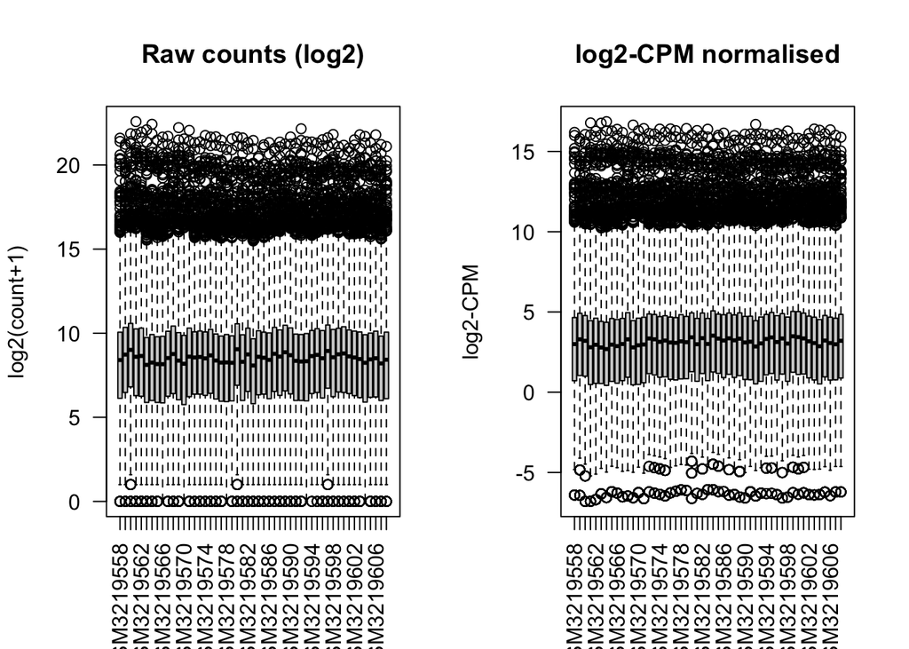

```r
# log2-CPM normalisation
# lib.size: total mapped reads per sample — used to make samples comparable
# regardless of sequencing depth. +0.5 / +1 are pseudocounts to avoid log(0).
lib.size <- colSums(filtered116250)
y <- t(log2(t(filtered116250 + 0.5) / (lib.size + 1) * 1e6))

# Boxplot: raw counts vs log2-CPM — distributions should be roughly even across samples
par(mfrow = c(1, 2))
boxplot(log2(filtered116250 + 1),
        las = 2, main = "Raw counts (log2)", ylab = "log2(count+1)")
boxplot(y,
        las = 2, main = "log2-CPM normalised", ylab = "log2-CPM")
```

```r
expr_gse116250 <- y
cat("GSE116250 expression matrix dimensions:", dim(expr_gse116250), "\n")
```

```
## GSE116250 expression matrix dimensions: 18099 51
```

```r
cat("Value range:", round(min(expr_gse116250), 2), "—", round(max(expr_gse116250), 2), "\n")
```

```
## Value range: -6.8 — 16.86
```

## Step 7b: Filter GSE141910 Pre-normalised Values

GSE141910 Voom values are on a log2-CPM scale. The WGCNA FAQ threshold of 15 raw counts does not apply here. The standard limma/edgeR convention for log2-CPM data is to retain genes with log2-CPM > 1 (i.e. CPM > 2) in at least 25% of samples — equivalent to removing genes absent in more than 75% of samples.

```r
keep141910   <- rowSums(counts_gse141910 >= 1) >= ceiling(ncol(counts_gse141910) * 0.25)
expr_gse141910 <- as.matrix(counts_gse141910[keep141910, ])

cat("GSE141910 genes after expression filter:", nrow(expr_gse141910), "\n")
```

```
## GSE141910 genes after expression filter: 20781
```

```r
cat("Value range:", round(min(expr_gse141910), 2), "—", round(max(expr_gse141910), 2), "\n")
```

```
## Value range: 1 — 22.39
```

## Step 8: Harmonise Gene IDs to HGNC Gene Symbols

GSE116250 uses Entrez IDs; GSE141910 uses Ensembl IDs. Both are mapped to HGNC symbols so the two matrices share a common identifier for merging.

```r
# GSE116250: Entrez → HGNC symbol
symbols_116250 <- mapIds(
  org.Hs.eg.db,
  keys      = rownames(expr_gse116250),
  column    = "SYMBOL",
  keytype   = "ENTREZID",
  multiVals = "first"
)
# Retain only genes with a unique, non-NA symbol
valid_116250   <- !is.na(symbols_116250) & !duplicated(symbols_116250)
expr_gse116250 <- expr_gse116250[valid_116250, ]
rownames(expr_gse116250) <- symbols_116250[valid_116250]

cat("GSE116250 genes after ID mapping:", nrow(expr_gse116250), "\n")
```

```
## GSE116250 genes after ID mapping: 17782
```

```r
# GSE141910: Ensembl → HGNC symbol
symbols_141910 <- mapIds(
  org.Hs.eg.db,
  keys      = rownames(expr_gse141910),
  column    = "SYMBOL",
  keytype   = "ENSEMBL",
  multiVals = "first"
)
valid_141910   <- !is.na(symbols_141910) & !duplicated(symbols_141910)
expr_gse141910 <- expr_gse141910[valid_141910, ]
rownames(expr_gse141910) <- symbols_141910[valid_141910]

cat("GSE141910 genes after ID mapping:", nrow(expr_gse141910), "\n")
```

```
## GSE141910 genes after ID mapping: 16978
```

## Step 8b: Sample Clustering Per Dataset (Visual Inspection Only)

These dendrograms let you visually assess each dataset before merging. **Nothing is removed here.** They are provided for reference only.

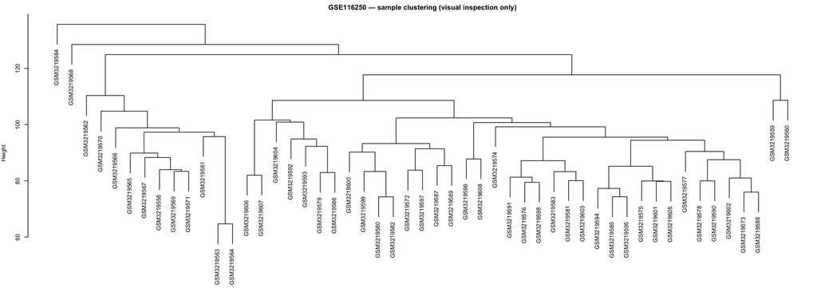

```r
sampleTree_116250 <- hclust(dist(t(expr_gse116250)), method = "average")

par(cex = 0.6, mar = c(0, 4, 2, 0))
plot(
  sampleTree_116250,
  main = "GSE116250 — sample clustering (visual inspection only)",
  sub  = "", xlab = "", ylab = "Height"
)
```

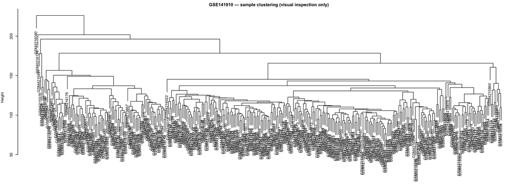

```r
sampleTree_141910 <- hclust(dist(t(expr_gse141910)), method = "average")

par(cex = 0.6, mar = c(0, 4, 2, 0))
plot(
  sampleTree_141910,
  main = "GSE141910 — sample clustering (visual inspection only)",
  sub  = "", xlab = "", ylab = "Height"
)
```

## Step 9: Combine Matrices

```r
# Find genes present in both datasets
common_genes <- intersect(rownames(expr_gse116250), rownames(expr_gse141910))
cat("Genes common to both datasets:", length(common_genes), "\n")
```

```
## Genes common to both datasets: 14900
```

```r
# Subset both matrices to common genes in the same row order
expr_116250_common <- expr_gse116250[common_genes, ]
expr_141910_common <- expr_gse141910[common_genes, ]

# Merge into a single expression matrix (genes × all samples)
combined_expr <- cbind(expr_116250_common, expr_141910_common)
cat("Combined matrix dimensions (genes × samples):", dim(combined_expr), "\n")
```

```
## Combined matrix dimensions (genes × samples): 14900 383
```

```r
# Build combined metadata
# age and sex were extracted in Step 3; they are carried through here so that
# Step 13 can use them as additional trait columns in the heatmap
combined_meta <- bind_rows(
  pheno_gse116250 %>% dplyr::select(geo_accession, condition, age, sex) %>% mutate(dataset = "GSE116250"),
  pheno_gse141910 %>% dplyr::select(geo_accession, condition, age, sex) %>% mutate(dataset = "GSE141910")
)
rownames(combined_meta) <- combined_meta$geo_accession

cat("Clinical covariate availability:\n")
```

```
## Clinical covariate availability:
```

```r
cat("  Age — non-missing:", sum(!is.na(combined_meta$age)), "/ total:", nrow(combined_meta), "\n")
```

```
##   Age — non-missing: 383 / total: 383
```

```r
cat("  Sex — non-missing:", sum(!is.na(combined_meta$sex)), "/ total:", nrow(combined_meta), "\n")
```

```
##   Sex — non-missing: 383 / total: 383
```

```r
# Confirm columns of expression matrix match rows of metadata
stopifnot(all(colnames(combined_expr) == rownames(combined_meta)))
cat("Expression matrix and metadata alignment confirmed.\n")
```

```
## Expression matrix and metadata alignment confirmed.
```

## Step 10: Batch Correction with ComBat

```r
# Batch vector: 1 = GSE116250, 2 = GSE141910
batch <- ifelse(combined_meta$dataset == "GSE116250", 1, 2)
cat("Samples per batch:", table(batch), "\n")
```

```
## Samples per batch: 51 332
```

```r
# Model matrix preserving the biological condition
mod <- model.matrix(~ factor(combined_meta$condition))

# ComBat expects genes × samples (combined_expr is already in that orientation)
combined_expr_corrected <- ComBat(
  dat   = combined_expr,
  batch = batch,
  mod   = mod
)

cat("Batch-corrected matrix dimensions (genes × samples):",
    dim(combined_expr_corrected), "\n")
```

```
## Batch-corrected matrix dimensions (genes × samples): 14900 383
```

```r
# Transpose to samples × genes for WGCNA
wgcna_input <- t(combined_expr_corrected)
cat("WGCNA input dimensions (samples × genes):", dim(wgcna_input), "\n")
```

```
## WGCNA input dimensions (samples × genes): 383 14900
```

## Step 11: Soft-Thresholding Power Selection

```r
powers <- c(1:10, seq(12, 30, by = 2))

sft <- pickSoftThreshold(
  wgcna_input,
  powerVector = powers,
  networkType = "signed",
  verbose     = 5
)
```

```
## pickSoftThreshold: will use block size 3002.
##  pickSoftThreshold: calculating connectivity for given powers...
##    ..working on genes 1 through 3002 of 14900
##    ..working on genes 3003 through 6004 of 14900
##    ..working on genes 6005 through 9006 of 14900
##    ..working on genes 9007 through 12008 of 14900
##    ..working on genes 12009 through 14900 of 14900
##    Power SFT.R.sq  slope truncated.R.sq mean.k. median.k. max.k.
## 1      1  0.55400 26.700          0.987  7700.0   7690.00   8250
## 2      2  0.42500  8.910          0.916  4440.0   4370.00   5500
## 3      3  0.20900  2.930          0.818  2770.0   2690.00   4120
## 4      4  0.00175  0.109          0.648  1840.0   1750.00   3290
## 5      5  0.25000 -0.784          0.740  1290.0   1180.00   2720
## 6      6  0.54200 -1.070          0.810   937.0    819.00   2300
## 7      7  0.65100 -1.200          0.821   704.0    581.00   1980
## 8      8  0.69700 -1.230          0.829   542.0    419.00   1730
## 9      9  0.71200 -1.260          0.832   427.0    306.00   1520
## 10    10  0.72400 -1.270          0.845   342.0    226.00   1350
## 11    12  0.72800 -1.300          0.854   230.0    128.00   1090
## 12    14  0.72000 -1.350          0.862   161.0     73.70    891
## 13    16  0.73100 -1.370          0.882   117.0     43.70    742
## 14    18  0.74400 -1.390          0.900    87.1     26.50    626
## 15    20  0.74800 -1.420          0.910    66.3     16.30    533
## 16    22  0.75700 -1.430          0.923    51.4     10.20    457
## 17    24  0.76400 -1.450          0.932    40.4      6.55    395
## 18    26  0.77100 -1.460          0.939    32.2      4.24    344
## 19    28  0.77400 -1.470          0.945    25.9      2.81    301
## 20    30  0.78000 -1.490          0.950    21.1      1.89    264
```

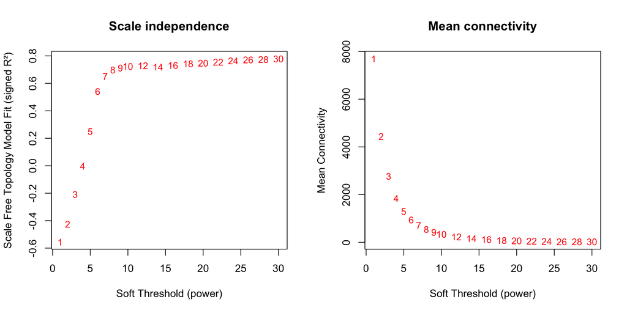

```r
par(mfrow = c(1, 2))

plot(
  sft$fitIndices[, 1],
  -sign(sft$fitIndices[, 3]) * sft$fitIndices[, 2],
  xlab = "Soft Threshold (power)",
  ylab = "Scale Free Topology Model Fit (signed R²)",
  type = "n",
  main = "Scale independence"
)
text(
  sft$fitIndices[, 1],
  -sign(sft$fitIndices[, 3]) * sft$fitIndices[, 2],
  labels = powers, cex = 0.9, col = "red"
)
abline(h = 0.85, col = "red", lty = 2)

plot(
  sft$fitIndices[, 1],
  sft$fitIndices[, 5],
  xlab = "Soft Threshold (power)",
  ylab = "Mean Connectivity",
  type = "n",
  main = "Mean connectivity"
)
text(
  sft$fitIndices[, 1],
  sft$fitIndices[, 5],
  labels = powers, cex = 0.9, col = "red"
)
```

```r
# Show R² and mean connectivity for all tested powers to inform the choice
sft$fitIndices %>%
  mutate(signed_r2 = -sign(slope) * SFT.R.sq) %>%
  dplyr::select(Power, signed_r2, mean.k.) %>%
  print()
```

```
##    Power    signed_r2    mean.k.
## 1      1 -0.553998871 7698.76604
## 2      2 -0.425362654 4436.41498
## 3      3 -0.209284504 2772.93922
## 4      4 -0.001747737 1844.94249
## 5      5  0.250103855 1289.44137
## 6      6  0.541950973  937.44025
## 7      7  0.651117024  703.66227
## 8      8  0.697293870  542.17961
## 9      9  0.711503645  426.87795
## 10    10  0.724126116  342.20522
## 11    12  0.728467880  229.62764
## 12    14  0.719541425  161.11835
## 13    16  0.730826496  116.93295
## 14    18  0.743785268   87.13955
## 15    20  0.747971342   66.33627
## 16    22  0.756567665   51.39616
## 17    24  0.764330120   40.41571
## 18    26  0.771165085   32.18748
## 19    28  0.774319287   25.91895
## 20    30  0.779793225   21.07473
```

```r
# Choose the lowest power where signed R² ≥ 0.85
candidates <- sft$fitIndices %>%
  mutate(signed_r2 = -sign(slope) * SFT.R.sq) %>%
  filter(signed_r2 >= 0.85)

if (nrow(candidates) > 0) {
  cat("Lowest power reaching R² ≥ 0.85:", candidates %>% slice(1) %>% pull(Power), "\n")
} else {
  cat("No power reached R² ≥ 0.85 — selecting manually.\n")
}
```

```
## No power reached R² ≥ 0.85 — selecting manually.
```

```r
# Power 12 is selected by convention for signed networks when no single power
# clearly reaches R² ≥ 0.85, following the WGCNA FAQ recommendation for
# RNA-seq data (Langfelder & Horvath suggest power 12 as a default for
# signed networks when the scale-free criterion is not cleanly met)
soft_power <- 12
cat("Selected soft-thresholding power:", soft_power, "\n")
```

```
## Selected soft-thresholding power: 12
```

```r
# Confirm R² and mean connectivity at chosen power
idx       <- which(sft$fitIndices$Power == soft_power)
signed_r2 <- -sign(sft$fitIndices$slope[idx]) * sft$fitIndices$SFT.R.sq[idx]
cat("Scale-free R² at power", soft_power, ":", round(signed_r2, 3), "\n")
```

```
## Scale-free R² at power 12 : 0.728
```

```r
cat("Mean connectivity at power", soft_power, ":", round(sft$fitIndices[idx, 5], 1), "\n")
```

```
## Mean connectivity at power 12 : 229.6
```

## Step 12: Network Construction and Module Detection

`blockwiseModules()` performs the core WGCNA computation in a single call:

1. Raises the correlation matrix to `soft_power` to approximate a scale-free topology
2. Computes the **Topological Overlap Matrix (TOM)** — a measure of how similarly connected two genes are across the whole network (more robust than raw correlation)
3. Clusters genes hierarchically on 1 − TOM distance
4. Cuts the dendrogram into **modules** (branches) using dynamic tree cutting
5. Merges modules whose eigengenes are highly similar (`mergeCutHeight = 0.25` means modules sharing >75% eigengene correlation are collapsed)

Genes that do not cluster into any module are assigned to the **grey module (label 0)** and excluded from downstream analysis.

```r
# WGCNA's cor() is used internally; explicitly prefer it over base R's cor()
# to avoid namespace conflicts introduced by loading other packages
conflicts_prefer(WGCNA::cor)

bwnet <- blockwiseModules(
  wgcna_input,
  power             = soft_power,  # soft-thresholding power chosen in Step 11

  # signed network: distinguishes positive (co-expressed) from negative
  # (anti-correlated) gene relationships — appropriate for biological data
  # where direction of co-expression is meaningful
  networkType       = "signed",
  TOMType           = "signed",

  # Module detection parameters
  minModuleSize     = 30,    # modules must contain at least 30 genes
  mergeCutHeight    = 0.25,  # merge modules whose eigengenes correlate > 0.75

  # Process all genes in a single block (avoids artefacts from block-splitting)
  # Requires sufficient RAM; reduce if memory errors occur
  maxBlockSize      = ncol(wgcna_input),

  numericLabels     = TRUE,  # modules labelled 0, 1, 2... (0 = grey/unassigned)
  saveTOMs          = FALSE,
  verbose           = 3
)
```

```
##  Calculating module eigengenes block-wise from all genes
##    Flagging genes and samples with too many missing values...
##     ..step 1
##  ..Working on block 1 .
##     TOM calculation: adjacency..
##     ..will use 8 parallel threads.
##      Fraction of slow calculations: 0.000000
##     ..connectivity..
##     ..matrix multiplication (system BLAS)..
##     ..normalization..
##     ..done.
##  ....clustering..
##  ....detecting modules..
##  ....calculating module eigengenes..
##  ....checking kME in modules..
##      ..removing 769 genes from module 1 because their KME is too low.
##      ..removing 533 genes from module 2 because their KME is too low.
##      ..removing 285 genes from module 3 because their KME is too low.
##      ..removing 402 genes from module 4 because their KME is too low.
##      ..removing 63 genes from module 5 because their KME is too low.
##      ..removing 22 genes from module 6 because their KME is too low.
##      ..removing 3 genes from module 8 because their KME is too low.
##      ..removing 2 genes from module 11 because their KME is too low.
##      ..removing 1 genes from module 14 because their KME is too low.
##   ..reassigning 634 genes from module 1 to modules with higher KME.
##   ..reassigning 232 genes from module 2 to modules with higher KME.
##   ..reassigning 532 genes from module 3 to modules with higher KME.
##   ..reassigning 458 genes from module 4 to modules with higher KME.
##   ..reassigning 111 genes from module 5 to modules with higher KME.
##   ..reassigning 78 genes from module 6 to modules with higher KME.
##   ..reassigning 18 genes from module 7 to modules with higher KME.
##   ..reassigning 7 genes from module 8 to modules with higher KME.
##   ..reassigning 14 genes from module 9 to modules with higher KME.
##   ..reassigning 7 genes from module 10 to modules with higher KME.
##   ..reassigning 13 genes from module 11 to modules with higher KME.
##   ..reassigning 4 genes from module 12 to modules with higher KME.
##   ..reassigning 7 genes from module 13 to modules with higher KME.
##   ..reassigning 1 genes from module 14 to modules with higher KME.
##  ..merging modules that are too close..
##      mergeCloseModules: Merging modules whose distance is less than 0.25
##        Calculating new MEs...
```

```r
# Convert numeric module labels to colour names (WGCNA convention)
# e.g. 0 = "grey", 1 = "turquoise", 2 = "blue", etc.
module_labels  <- bwnet$colors
module_colours <- labels2colors(module_labels)

cat("Number of modules detected (excluding grey):",
    length(unique(module_labels[module_labels != 0])), "\n")
```

```
## Number of modules detected (excluding grey): 11
```

```r
cat("Module sizes (number of genes per module):\n")
```

```
## Module sizes (number of genes per module):
```

```r
print(table(module_colours))
```

```
## module_colours
##       black        blue       brown       green greenyellow        grey
##         308        3305        1351         325          80        2087
##     magenta        pink      purple         red   turquoise      yellow
##         224         239         149         324        5997         511
```

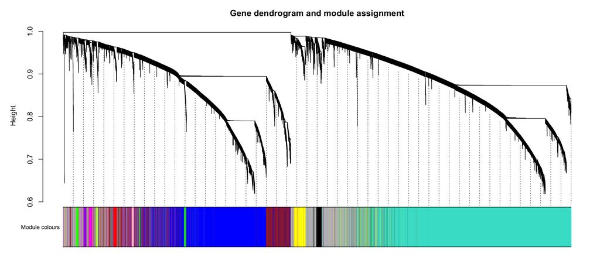

```r
# Gene dendrogram: branches represent groups of co-expressed genes.
# The colour bar beneath shows final module assignments after merging.
# Genes in grey are unassigned. Each distinct colour is one module.
plotDendroAndColors(
  bwnet$dendrograms[[1]],
  module_colours[bwnet$blockGenes[[1]]],
  "Module colours",
  dendroLabels = FALSE,
  hang         = 0.03,
  addGuide     = TRUE,
  guideHang    = 0.05,
  main         = "Gene dendrogram and module assignment"
)
```

## Step 13: Module–Trait Correlation

Each module is summarised by its **module eigengene (ME)** — the first principal component of the expression matrix for all genes in that module. The ME captures the dominant expression pattern shared across the module’s genes and acts as a representative expression profile for the whole module.

We correlate each ME with four traits:

- **DCM:** the primary biological question — which modules are upregulated or downregulated in DCM relative to non-failing hearts?
- **Age:** continuous clinical covariate; identifies modules tracking patient age independently of disease status.
- **Sex:** binary clinical covariate (Male = 1, Female = 0); identifies sex-biased expression modules.
- **Dataset:** a quality control check — after ComBat batch correction, no module should remain strongly correlated with study origin (GSE116250 vs GSE141910). A module still tracking dataset after correction likely reflects residual technical variation rather than biology.

Age and sex may have missing values for some samples; `use = "pairwise.complete.obs"` ensures those samples are excluded per trait rather than dropping them globally.

Each cell in the heatmap shows the Pearson **r** (correlation strength, −1 to 1) and its raw **p-value**. Red = positive correlation; blue = negative correlation.

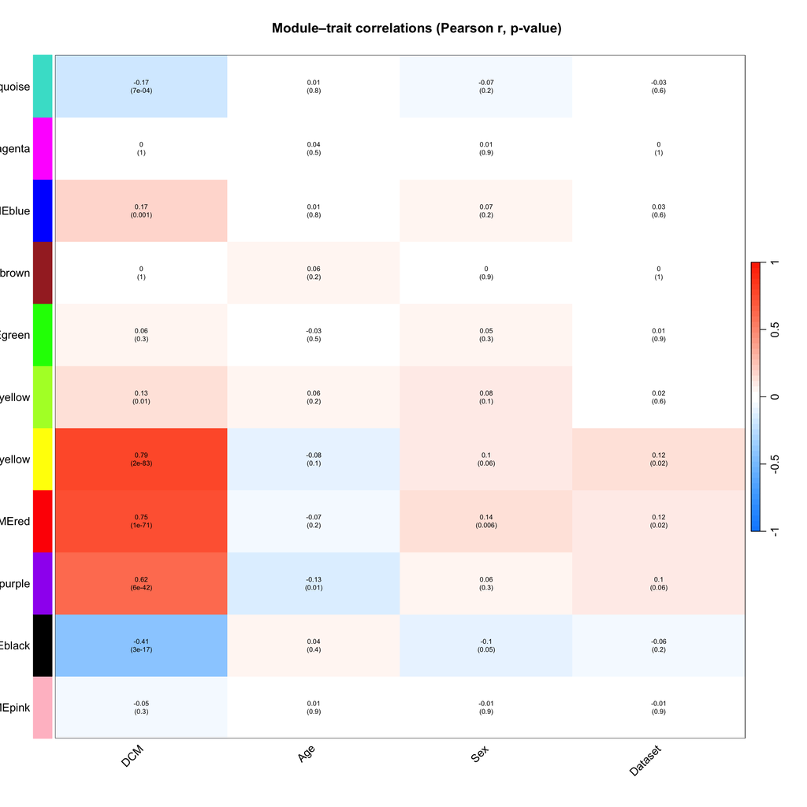

```r
# Extract module eigengenes computed during blockwiseModules()
# MEs is a samples × modules matrix; each column is one module's eigengene
MEs <- bwnet$MEs

# blockwiseModules returns numeric labels (ME0, ME1, ...); convert to colour names
# so the heatmap rows are labelled e.g. MEturquoise, MEblue, etc.
ME_colours    <- paste0("ME", labels2colors(as.numeric(gsub("ME", "", colnames(MEs)))))
colnames(MEs) <- ME_colours

# Remove MEgrey — the grey module contains unassigned genes and has no
# coherent biological meaning; correlating it with a trait is uninformative
MEs <- MEs[, colnames(MEs) != "MEgrey"]

# Trait data frame: one row per sample, one column per trait
# DCM     = 1 (disease), 0 (control) — primary biological variable
# Age     = continuous (years); may be NA for some samples
# Sex     = 1 (Male), 0 (Female), NA (unknown) — binary clinical covariate
# Dataset = 1 (GSE116250), 0 (GSE141910) — batch sanity check only
trait_df <- data.frame(
  DCM     = ifelse(combined_meta$condition == "DCM", 1, 0),
  Age     = combined_meta$age,
  Sex     = combined_meta$sex,
  Dataset = ifelse(combined_meta$dataset == "GSE116250", 1, 0)
)
rownames(trait_df) <- rownames(combined_meta)
nSamples <- nrow(wgcna_input)

# Pearson correlation between each eigengene and each trait.
# pairwise.complete.obs: for Age and Sex, only samples with non-NA values are
# used when computing those correlations — other samples are not dropped globally.
# corPvalueStudent() converts r to a t-statistic p-value using n − 2 df;
# for Age/Sex the effective n may be smaller due to missing values.
module_trait_cor <- cor(MEs, trait_df, use = "pairwise.complete.obs")
module_trait_p   <- corPvalueStudent(module_trait_cor, nSamples)

# Build the cell text: r on top line, p-value in parentheses below
text_matrix <- paste0(
  round(module_trait_cor, 2), "\n(",
  signif(module_trait_p, 1), ")"
)
dim(text_matrix) <- dim(module_trait_cor)

# Heatmap: each row is a module, columns are DCM and Dataset
# Red  = positive correlation with trait (higher expression in DCM / in GSE116250)
# Blue = negative correlation (lower expression in DCM / in GSE141910)
# White = no correlation
labeledHeatmap(
  Matrix        = module_trait_cor,
  xLabels       = colnames(trait_df),
  yLabels       = colnames(MEs),
  ySymbols      = colnames(MEs),
  colorLabels   = FALSE,
  colors        = blueWhiteRed(50),
  textMatrix    = text_matrix,
  setStdMargins = FALSE,
  cex.text      = 0.6,
  zlim          = c(-1, 1),
  main          = "Module–trait correlations (Pearson r, p-value)"
)
```

```r
# Filter to modules significantly associated with DCM after BH multiple-testing
# correction. Age, Sex, and Dataset columns are included for contextual interpretation:
#   r_age / r_sex  — check whether a module is driven by a confounding clinical variable
#   r_dataset      — batch sanity check; should be near 0 after ComBat
sig_modules <- data.frame(
  module    = colnames(MEs),
  r_DCM     = round(module_trait_cor[, "DCM"],     3),
  p_value   = signif(module_trait_p[,  "DCM"],     3),
  p_adj     = signif(p.adjust(module_trait_p[, "DCM"], method = "BH"), 3),
  r_age     = round(module_trait_cor[, "Age"],     3),
  r_sex     = round(module_trait_cor[, "Sex"],     3),
  r_dataset = round(module_trait_cor[, "Dataset"], 3)
) %>%
  arrange(p_adj) %>%
  filter(p_adj < 0.05)

cat("Modules significantly correlated with DCM (FDR < 0.05):\n")
```

```
## Modules significantly correlated with DCM (FDR < 0.05):
```

```r
print(sig_modules)
```

```
##                      module  r_DCM  p_value    p_adj  r_age  r_sex r_dataset
## MEyellow           MEyellow  0.791 2.37e-83 2.61e-82 -0.082  0.097     0.122
## MEred                 MEred  0.754 1.19e-71 6.57e-71 -0.072  0.142     0.117
## MEpurple           MEpurple  0.620 5.70e-42 2.09e-41 -0.127  0.056     0.097
## MEblack             MEblack -0.414 2.92e-17 8.03e-17  0.040 -0.100    -0.063
## MEturquoise     MEturquoise -0.173 6.62e-04 1.46e-03  0.014 -0.068    -0.030
## MEblue               MEblue  0.167 1.05e-03 1.92e-03  0.014  0.068     0.025
## MEgreenyellow MEgreenyellow  0.127 1.31e-02 2.06e-02  0.061  0.081     0.023
```

```r
# Sanity check: a DCM-significant module with |r_dataset| > 0.3 may be driven
# by study origin rather than true disease biology — interpret with caution
confounded <- sig_modules %>% filter(abs(r_dataset) > 0.3)
if (nrow(confounded) > 0) {
  cat("\nWARNING — these modules may retain batch signal (|r_dataset| > 0.3):\n")
  print(confounded$module)
} else {
  cat("\nNo DCM-significant modules show strong dataset correlation. ComBat successful.\n")
}
```

```
##
## No DCM-significant modules show strong dataset correlation. ComBat successful.
```

## Step 14: Hub Gene Identification

**Module membership (kME)** is the Pearson correlation between a gene’s expression profile and the module eigengene. A gene with kME close to 1 is tightly co-expressed with the rest of the module; a gene with low kME sits on the module periphery.

**Hub genes** are defined as genes with the highest kME — they are the most central nodes in the co-expression network and represent the strongest candidate regulators or biomarkers for the biological process captured by each module.

```r
# signedKME() computes the correlation between every gene and every module eigengene.
# The result is a genes × modules matrix; each column is named kME<colour>.
# Positive kME = gene expression moves with the eigengene (co-expressed with module).
# Negative kME = gene expression moves against the eigengene (anti-correlated).
kME <- signedKME(wgcna_input, MEs, outputColumnName = "kME")

sig_module_names <- sig_modules$module

# For each DCM-significant module, rank all module genes by kME and keep top 20
hub_genes <- lapply(sig_module_names, function(mod) {
  colour  <- gsub("ME", "", mod)
  kme_col <- paste0("kME", colour)  # e.g. kMEturquoise

  data.frame(
    gene   = rownames(kME),
    module = mod,
    kME    = kME[[kme_col]]
  ) %>%
    arrange(desc(kME)) %>%
    slice(1:20)
})

hub_genes_df <- bind_rows(hub_genes)

cat("Top 20 hub genes per significant module (ranked by kME):\n")
```

```
## Top 20 hub genes per significant module (ranked by kME):
```

```r
print(hub_genes_df)
```

```
##           gene        module       kME
## 1          LUM      MEyellow 0.9087093
## 2          OGN      MEyellow 0.8999658
## 3        FREM1      MEyellow 0.8962372
## 4       ANTXR1      MEyellow 0.8960382
## 5         ASPN      MEyellow 0.8937937
## 6     CRISPLD1      MEyellow 0.8926339
## 7          NRK      MEyellow 0.8912832
## 8        PDE5A      MEyellow 0.8794660
## 9         ECM2      MEyellow 0.8762806
## 10      GLT8D2      MEyellow 0.8735238
## 11     COL14A1      MEyellow 0.8729878
## 12       SULF1      MEyellow 0.8707333
## 13     C1QTNF7      MEyellow 0.8703952
## 14       SYTL2      MEyellow 0.8639335
```

[output cut: 126 more lines]

[figure not shown]

```r
# Dot plot showing kME of the top 20 hub genes per module.
# Genes are sorted by kME (highest at top). Each facet is one module.
# These are the candidate driver genes for further investigation.
ggplot(hub_genes_df, aes(x = reorder(gene, kME), y = kME, colour = module)) +
  geom_point(size = 2) +
  facet_wrap(~ module, scales = "free_x") +
  coord_flip() +
  labs(
    x     = "Gene",
    y     = "Module membership (kME)",
    title = "Top 20 hub genes per DCM-associated module"
  ) +
  theme_bw() +
  theme(legend.position = "none")
```

## Step 15: Gene Significance vs Module Membership

This plot validates the biological relevance of each significant module by comparing two independent measures for every gene:

- **Gene Significance (GS):** the absolute Pearson correlation between a gene’s expression and the DCM trait (1 = disease, 0 = control). A high GS means the gene is individually dysregulated in DCM, regardless of which module it belongs to.
- **Module Membership (MM / kME):** how tightly a gene co-expresses with its module eigengene (from Step 14). A high MM means the gene is a central hub of the module.

**Interpretation:** If a module genuinely captures DCM biology, its hub genes (high MM) should also be the most disease-associated genes (high GS). A strong positive correlation between GS and MM within a module (r close to 1) confirms this. A flat or weak relationship suggests the module has internal co-expression structure but is not directly relevant to the DCM phenotype.

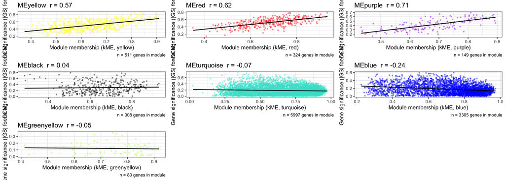

```r
# Compute Gene Significance: correlate every gene with the binary DCM trait.
# Result is a genes × 1 matrix; convert to data frame for easier handling.
GS_DCM <- cor(wgcna_input, trait_df$DCM, use = "p")
GS_DCM <- as.data.frame(GS_DCM)
colnames(GS_DCM) <- "GS"

# One scatter plot per significant module
gs_mm_plots <- lapply(sig_module_names, function(mod) {
  colour  <- gsub("ME", "", mod)
  kme_col <- paste0("kME", colour)

  # Restrict to genes actually assigned to this module
  in_module <- module_colours == colour

  df <- data.frame(
    MM = kME[[kme_col]][in_module],  # module membership for genes in this module
    GS = abs(GS_DCM$GS[in_module])  # absolute GS (direction already captured by r_DCM)
  )

  # Within-module GS–MM correlation: high r validates biological relevance
  r_val <- round(cor(df$MM, df$GS, use = "p"), 2)

  ggplot(df, aes(x = MM, y = GS)) +
    geom_point(alpha = 0.4, size = 0.8, colour = colour) +
    geom_smooth(method = "lm", se = FALSE, colour = "black", linewidth = 0.7) +
    labs(
      x       = paste0("Module membership (kME, ", colour, ")"),
      y       = "Gene significance (|GS| for DCM)",
      title   = paste0(mod, "  r = ", r_val),
      caption = paste0("n = ", sum(in_module), " genes in module")
    ) +
    theme_bw()
})

# Display all module plots side by side (max 3 per row)
n_cols <- min(3, length(gs_mm_plots))
do.call(gridExtra::grid.arrange, c(gs_mm_plots, ncol = n_cols))
```

```r
# Summary table: GS–MM correlation coefficient and significance per module.
# High r_GS_MM = hub genes are the most disease-relevant genes = biologically valid.
# Low r_GS_MM  = module structure is real but not driven by DCM phenotype.
gs_mm_stats <- lapply(sig_module_names, function(mod) {
  colour    <- gsub("ME", "", mod)
  kme_col   <- paste0("kME", colour)
  in_module <- module_colours == colour

  mm <- kME[[kme_col]][in_module]
  gs <- abs(GS_DCM$GS[in_module])

  data.frame(
    module   = mod,
    r_GS_MM  = round(cor(mm, gs, use = "p"), 3),
    p_value  = signif(cor.test(mm, gs)$p.value, 3),
    n_genes  = sum(in_module)
  )
})

gs_mm_stats_df <- bind_rows(gs_mm_stats)
cat("GS–MM correlation per significant module:\n")
```

```
## GS–MM correlation per significant module:
```

```r
print(gs_mm_stats_df)
```

```
##          module r_GS_MM  p_value n_genes
## 1      MEyellow   0.566 1.10e-44     511
## 2         MEred   0.624 2.14e-36     324
## 3      MEpurple   0.706 8.23e-24     149
## 4       MEblack   0.039 4.99e-01     308
## 5   MEturquoise  -0.075 6.17e-09    5997
## 6        MEblue  -0.235 9.88e-43    3305
## 7 MEgreenyellow  -0.047 6.78e-01      80
```